# Génération de réseaux

AH, SD, FJ, JC

25 March, 2020

## Préliminaires

```r
library(igraph)
library(corrplot)
library(Matrix)
```

## Paramètres du réseau

On défnit par exemple un réseau avec 12O noeuds et une structure de 4 blocs:

```r
p  <- 120
sizes <- c(50, 30, 30, 10)
K <- length(sizes)
PI <- diag(.4, K) + .05 # connectivity matrix
```

## Tirage d’un SBM

Le package `igraph` permet de tirer un SBM binaire sous ces paramètres [^1].

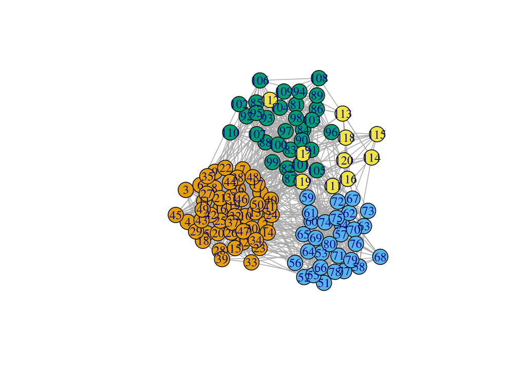

```r
mySBM <- igraph::sample_sbm(p, PI, sizes)
mySBM <- set_vertex_attr(mySBM, "cluster", value = rep(1:K, sizes))
plot(mySBM, vertex.color = V(mySBM)$cluster)
```

## Tirage des poids

On prends les poids Gaussiens de même moyenne et même variance[^2]

```r
## random Gaussian weights
mu <- 2; sigma <- 1
mySBM <- set_edge_attr(mySBM, "weight", value = rnorm(gsize(mySBM), mu , sigma))
```

## Construction de la matrice de précision et de variance-covariance

### Premier essai: laplacien pondéré, normalisé et diagonale dominante uniforme

On construit la matrice de précision à l’aide de l’opérateur Laplacien pondéré (et normalisé, pour avoir des variances autour de 1). Pour obtenir une matrice défini positive dont la structure soit fidèle au modèle graphique du SBM tiré ci-dessus, on rend cette matrice diagonale dominante en inflantant que la diagonale.

```r
epsilon <- 1e-1
Theta <- laplacian_matrix(mySBM, normalized = TRUE)
Theta <- Theta + diag(epsilon, p, p)
```

La matrice de covariance s’obtient par inversion directe:

```r
Sigma <- solve(Theta)
```

On ôte pour la représentation graphique les diagonales (qui sont autour de 1) pour constater que la structure apr bloc est bien préservée.

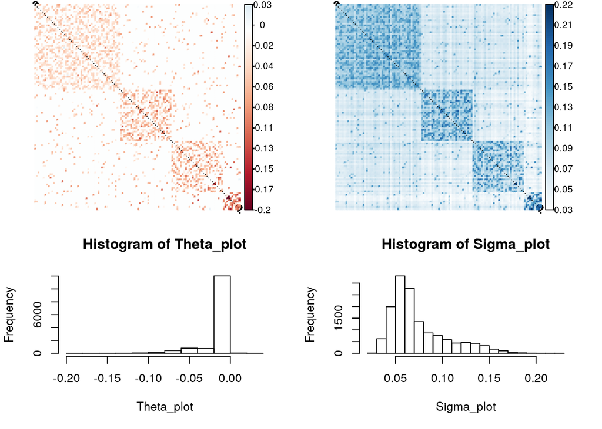

```r
par(mfrow = c(2,2))
Theta_plot <- as.matrix(Theta); diag(Theta_plot) <- NA
Sigma_plot <- as.matrix(Sigma); diag(Sigma_plot) <- NA
corrplot(Theta_plot, method = "color", is.corr = FALSE, tl.pos = "n")
corrplot(Sigma_plot, method = "color", is.corr = FALSE, tl.pos = "n")
hist(Theta_plot)
hist(Sigma_plot)
```

On construit la matrice de précision à l’aide de l’opérateur Laplacien pondéré. Pour obtenir une matrice définie positive dont la structure soit fidèle au modèle graphique du SBM tiré ci-dessus, on rend cette matrice diagonale dominante en inflantant que la diagonale proportionnellement au degré de chaque noeud.

```r
Theta <- laplacian_matrix(mySBM)
epsilon <- 1e-2
lambda  <- 1e-4 * epsilon
iter <- 0
while (!all(eigen(Theta, only.values = TRUE)$values > epsilon)) {
  iter <- iter + 1
  diag(Theta) <- diag(Theta) + lambda * degree(mySBM)
}
cat("Il a fallu", iter, "itérations.")
```

```
## Il a fallu 472 itérations.
```

La matrice de covariance s’obtient par inversion directe:

```r
Sigma <- solve(Theta)
```

On ôte pour la représentation graphique les diagonales (qui sont autour de 1) pour constater que la structure apr bloc est bien préservée.

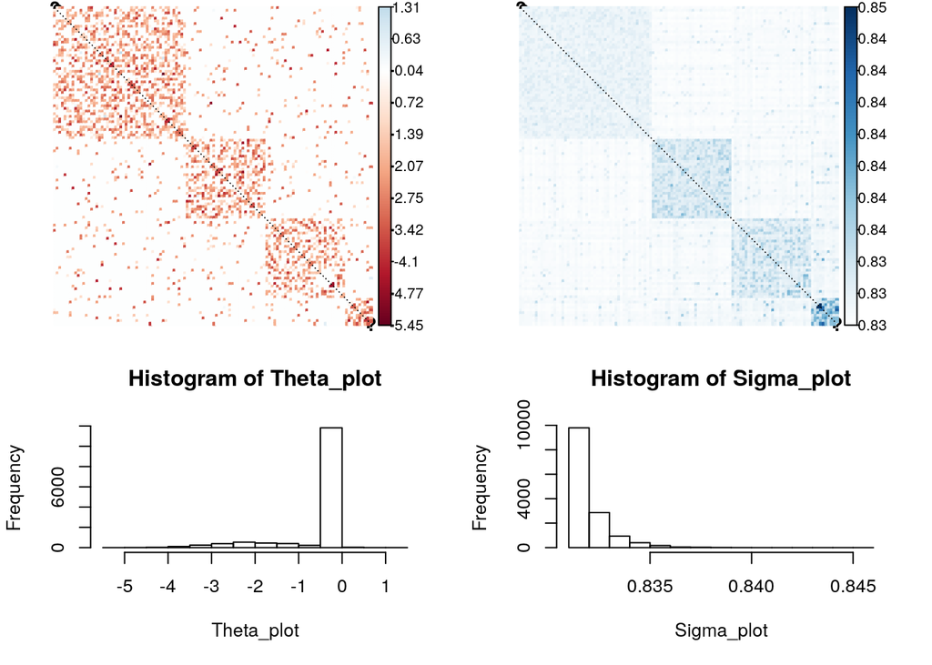

```r
par(mfrow = c(2,2))
Theta_plot <- as.matrix(Theta); diag(Theta_plot) <- NA
Sigma_plot <- as.matrix(Sigma); diag(Sigma_plot) <- NA
corrplot(Theta_plot, method = "color", is.corr = FALSE, tl.pos = "n")
corrplot(Sigma_plot, method = "color", is.corr = FALSE, tl.pos = "n")
hist(Theta_plot)
hist(Sigma_plot)
```

[^1]: les groupes sont fixés et les noeuds ordonnées dans les groupe correpondants
[^2]: Il y a mieux à faire !